# Cameron_Scratch_Sheet

Cameron Stewart

7/20/2021

Load Theme for plots

```r
theme_set(theme_fivethirtyeight())
theme_update(axis.title = element_text()) #the default for fivethirtyeight is to not show axis labels, this removes that default so we can choose to specify and display axis titles
theme_update(plot.title = element_text(hjust = 0.5)) # changing default to center all titles
```

Load Data downloaded from UCI and stored on github repo https://archive.ics.uci.edu/ml/datasets/Adult

```r
adult = read.csv("/Users/Camo/Documents/SMU_DS/Applied Stats/Project2/Predicting_Income/adult.data", header = FALSE)
```

Description of variables from UCI:

Response: >50K, <=50K.

age: continuous. workclass: Private, Self-emp-not-inc, Self-emp-inc, Federal-gov, Local-gov, State-gov, Without-pay, Never-worked. fnlwgt: continuous. education: Bachelors, Some-college, 11th, HS-grad, Prof-school, Assoc-acdm, Assoc-voc, 9th, 7th-8th, 12th, Masters, 1st-4th, 10th, Doctorate, 5th-6th, Preschool. education-num: continuous. marital-status: Married-civ-spouse, Divorced, Never-married, Separated, Widowed, Married-spouse-absent, Married-AF-spouse. occupation: Tech-support, Craft-repair, Other-service, Sales, Exec-managerial, Prof-specialty, Handlers-cleaners, Machine-op-inspct, Adm-clerical, Farming-fishing, Transport-moving, Priv-house-serv, Protective-serv, Armed-Forces. relationship: Wife, Own-child, Husband, Not-in-family, Other-relative, Unmarried. race: White, Asian-Pac-Islander, Amer-Indian-Eskimo, Other, Black. sex: Female, Male. capital-gain: continuous. capital-loss: continuous. hours-per-week: continuous. native-country: United-States, Cambodia, England, Puerto-Rico, Canada, Germany, Outlying-US(Guam-USVI-etc), India, Japan, Greece, South, China, Cuba, Iran, Honduras, Philippines, Italy, Poland, Jamaica, Vietnam, Mexico, Portugal, Ireland, France, Dominican-Republic, Laos, Ecuador, Taiwan, Haiti, Columbia, Hungary, Guatemala, Nicaragua, Scotland, Thailand, Yugoslavia, El-Salvador, Trinadad&Tobago, Peru, Hong, Holand-Netherlands.

Add column names to data set:

```r
# NOTE: names using underscore instead of hyphen so they can be referenced easier later
colnames(adult) <- c("age","workclass","fnlwgt","education","education_num","marital_status","occupation","relationship","race","sex","capital_gain","capital_loss","hours_per_week","native_country","income")
```

Investigate NA values to determine what needs resolution

```r
# aggr_plot <- aggr(adult, col=c('navyblue','red'), numbers=TRUE, sortVars=TRUE, labels=names(adult), cex.axis=.7, gap=3, ylab=c("Percent data missing","Combinations Missing"))
# #Note there are not missing values showing up initially but that's because the missing values are represented by "?" instead of NA

#Replace "?" with NA and re-do missing value analysis
adult[, 1:14][adult[, 1:14] == " ?"] <- NA

# aggr_plot <- aggr(adult, col=c('navyblue','red'), numbers=TRUE, sortVars=TRUE, labels=names(adult), cex.axis=.7, gap=3, ylab=c("Percent data missing","Combinations Missing"))
# marginplot(adult[c(2,7)])
# marginplot(adult[c(2,14)])
# marginplot(adult[c(7,14)])

#occupation missing 5.66% of values
#workclass missing 5.64% of values
#native-country missing 1.79& of values
#Note that half of the missing workclass values occur on observations that are also missing occupation
```

Examine formats of data available

```r
#Remove leading whitespace
adult[,c("workclass","education","marital_status","occupation","relationship","race","sex","native_country","income")]=as.data.frame(apply(adult[,c("workclass","education","marital_status","occupation","relationship","race","sex","native_country","income")],2,function(x)gsub('\\s+', '',x)))

#Convert character vars to factors and make list of vars
adult$workclass <- as.factor(adult$workclass)
adult$education <- as.factor(adult$education)
adult$marital_status <- as.factor(adult$marital_status)
adult$occupation <- as.factor(adult$occupation)
adult$relationship <- as.factor(adult$relationship)
adult$race <- as.factor(adult$race)
adult$sex <- as.factor(adult$sex)
adult$native_country <- as.factor(adult$native_country)
adult$income <- as.factor(adult$income)

categorical.explanatory = c("workclass","education","marital_status","occupation","relationship","race","sex","native_country")
```

#This is where I started making changes after Rick’s contribution above

Notes: -I corrected white space issue before variable types were corrected -I added additional libraries at top

Remaining missing values visualized

```r
#Proportion and total missing values
missing=data.frame(miss_var_cumsum(adult))
missing$prop_miss = missing$n_miss/dim(adult)[1]
missing[,-3] %>% arrange(-n_miss)
```

```
##          variable n_miss  prop_miss
## 1      occupation   1843 0.05660146
## 2       workclass   1836 0.05638647
## 3  native_country    583 0.01790486
## 4             age      0 0.00000000
## 5          fnlwgt      0 0.00000000
## 6       education      0 0.00000000
## 7   education_num      0 0.00000000
## 8  marital_status      0 0.00000000
## 9    relationship      0 0.00000000
## 10           race      0 0.00000000
## 11            sex      0 0.00000000
## 12   capital_gain      0 0.00000000
## 13   capital_loss      0 0.00000000
## 14 hours_per_week      0 0.00000000
## 15         income      0 0.00000000
```

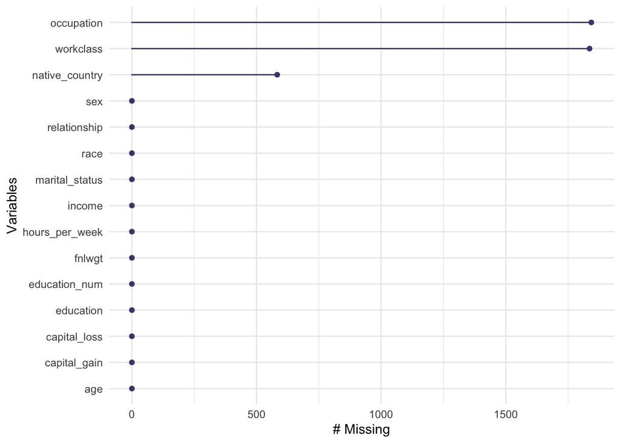

```r
#Chart of missing values by variable
gg_miss_var(adult)
```

Looking at categorical variable class balance

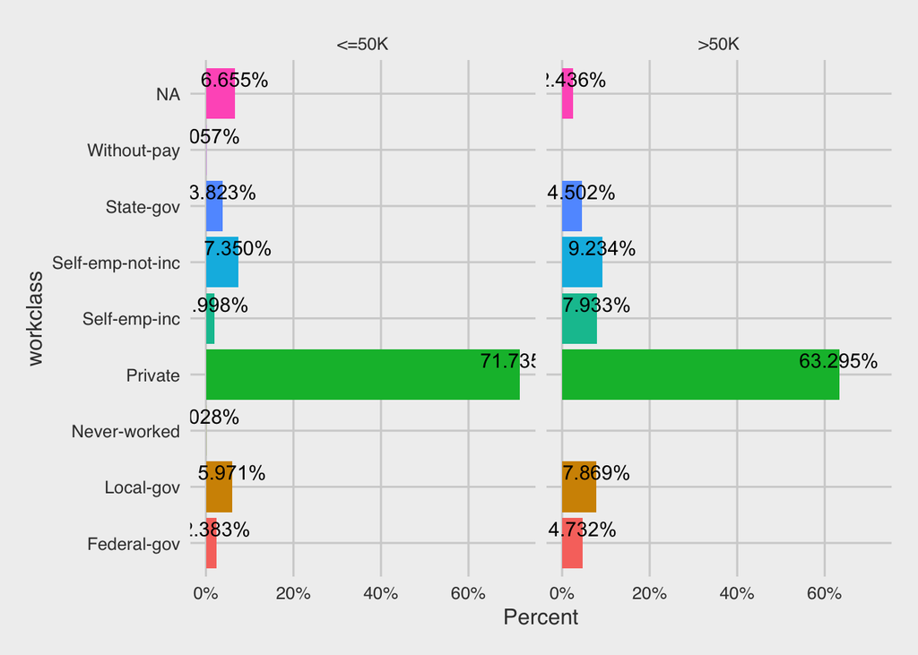

```r
cat_vars=adult[,c("workclass","education","marital_status","occupation","relationship","race","sex","native_country","income")]


#Notes on Workclass
#Disproportionate NAs on <=50K
#Significant difference in self-emp-inc
#Small differences elsewhere
ggplot(cat_vars, aes(x= workclass,  group=income)) +
    geom_bar(aes(y = ..prop.., fill = factor(..x..)), stat="count") +
    geom_text(aes( label = scales::percent(..prop..),
                   y= ..prop.. ), stat= "count", vjust = -.5) +
    labs(y = "Percent", fill="workclass") +
    facet_grid(~income) +
    scale_y_continuous(labels = scales::percent)+coord_flip()+theme(legend.position = "none")
```

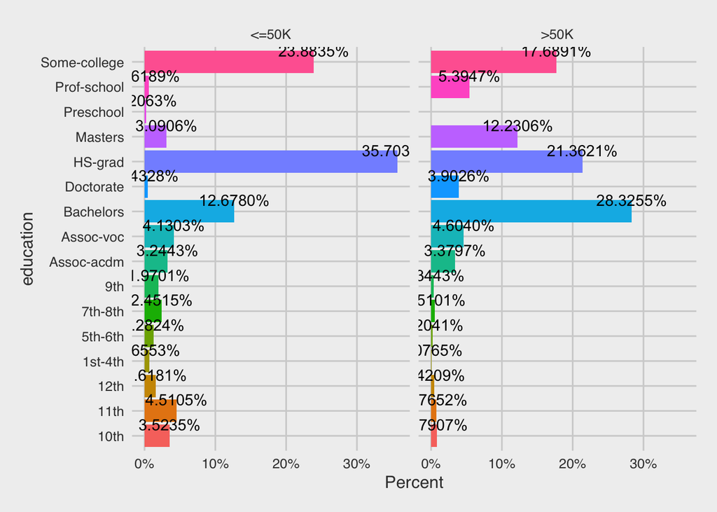

```r
##Notes on Education
#Assoc-voc and Assoc-acdm only not sig diff
ggplot(cat_vars, aes(x= education,  group=income)) +
    geom_bar(aes(y = ..prop.., fill = factor(..x..)), stat="count") +
    geom_text(aes( label = scales::percent(..prop..),
                   y= ..prop.. ), stat= "count", vjust = -.5) +
    labs(y = "Percent", fill="education") +
    facet_grid(~income) +
    scale_y_continuous(labels = scales::percent)+coord_flip()+theme(legend.position = "none")
```

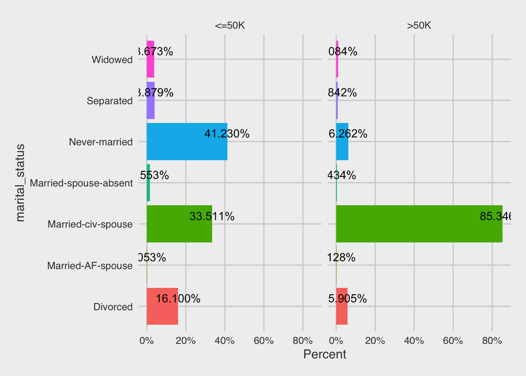

```r
##Notes on Marital Status
#Very sig differences in Married-civ-spouse, never-married,and divorced
ggplot(cat_vars, aes(x= marital_status,  group=income)) +
    geom_bar(aes(y = ..prop.., fill = factor(..x..)), stat="count") +
    geom_text(aes( label = scales::percent(..prop..),
                   y= ..prop.. ), stat= "count", vjust = -.5) +
    labs(y = "Percent", fill="marital_status") +
    facet_grid(~income) +
    scale_y_continuous(labels = scales::percent)+coord_flip()+theme(legend.position = "none")
```

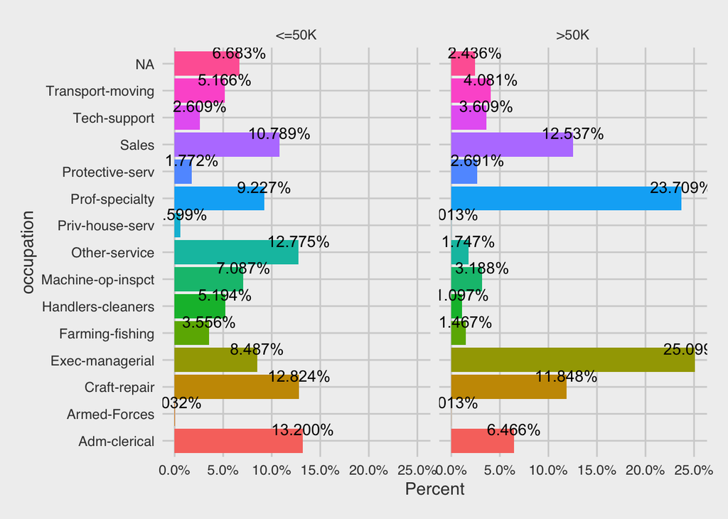

```r
ggplot(cat_vars, aes(x= occupation,  group=income)) +
    geom_bar(aes(y = ..prop.., fill = factor(..x..)), stat="count") +
    geom_text(aes( label = scales::percent(..prop..),
                   y= ..prop.. ), stat= "count", vjust = -.5) +
    labs(y = "Percent", fill="occupation") +
    facet_grid(~income) +
    scale_y_continuous(labels = scales::percent)+coord_flip()+theme(legend.position = "none")
```

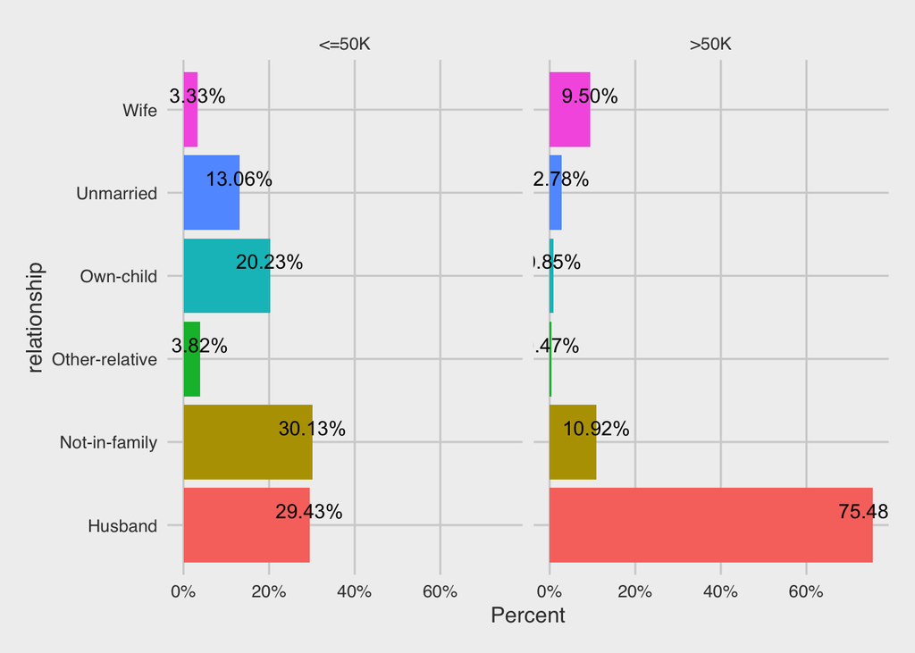

```r
ggplot(cat_vars, aes(x= relationship,  group=income)) +
    geom_bar(aes(y = ..prop.., fill = factor(..x..)), stat="count") +
    geom_text(aes( label = scales::percent(..prop..),
                   y= ..prop.. ), stat= "count", vjust = -.5) +
    labs(y = "Percent", fill="relationship") +
    facet_grid(~income) +
    scale_y_continuous(labels = scales::percent)+coord_flip()+theme(legend.position = "none")
```

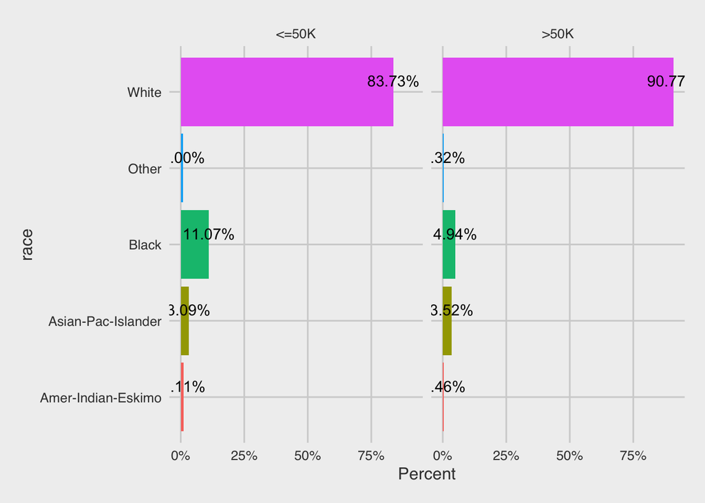

```r
ggplot(cat_vars, aes(x= race,  group=income)) +
    geom_bar(aes(y = ..prop.., fill = factor(..x..)), stat="count") +
    geom_text(aes( label = scales::percent(..prop..),
                   y= ..prop.. ), stat= "count", vjust = -.5) +
    labs(y = "Percent", fill="race") +
    facet_grid(~income) +
    scale_y_continuous(labels = scales::percent)+coord_flip()+theme(legend.position = "none")
```

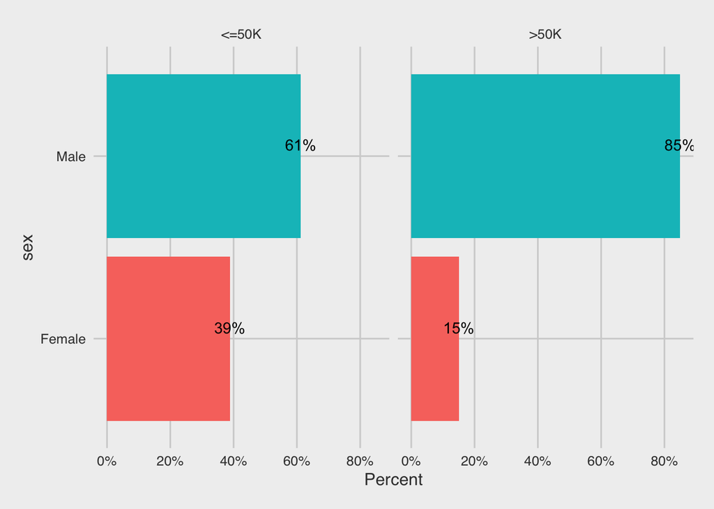

```r
ggplot(cat_vars, aes(x= sex,  group=income)) +
    geom_bar(aes(y = ..prop.., fill = factor(..x..)), stat="count") +
    geom_text(aes( label = scales::percent(..prop..),
                   y= ..prop.. ), stat= "count", vjust = -.5) +
    labs(y = "Percent", fill="sex") +
    facet_grid(~income) +
    scale_y_continuous(labels = scales::percent)+coord_flip()+theme(legend.position = "none")
```

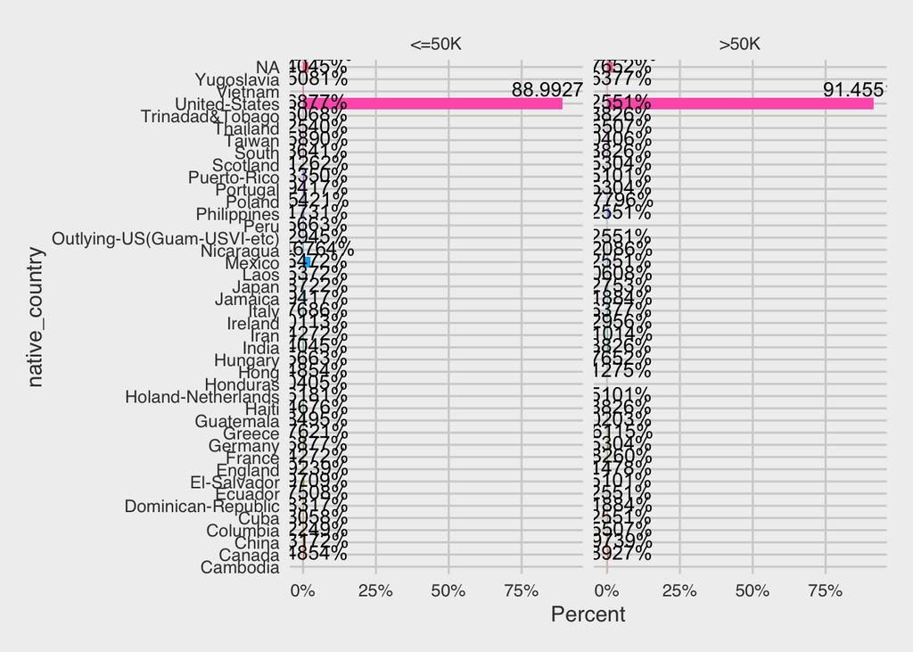

```r
ggplot(cat_vars, aes(x= native_country,  group=income)) +
    geom_bar(aes(y = ..prop.., fill = factor(..x..)), stat="count") +
    geom_text(aes( label = scales::percent(..prop..),
                   y= ..prop.. ), stat= "count", vjust = -.5) +
    labs(y = "Percent", fill="native_country") +
    facet_grid(~income) +
    scale_y_continuous(labels = scales::percent)+coord_flip()+theme(legend.position = "none")
```

```r
filt_cat_vars=filter(cat_vars, native_country != "United-States")
summary(filt_cat_vars$native_country)
```

```
##                   Cambodia                     Canada
##                         19                        121
##                      China                   Columbia
##                         75                         59
##                       Cuba         Dominican-Republic
##                         95                         70
##                    Ecuador                El-Salvador
##                         28                        106
##                    England                     France
##                         90                         29
##                    Germany                     Greece
##                        137                         29
##                  Guatemala                      Haiti
##                         64                         44
##         Holand-Netherlands                   Honduras
##                          1                         13
##                       Hong                    Hungary
##                         20                         13
##                      India                       Iran
##                        100                         43
##                    Ireland                      Italy
##                         24                         73
##                    Jamaica                      Japan
##                         81                         62
##                       Laos                     Mexico
##                         18                        643
##                  Nicaragua Outlying-US(Guam-USVI-etc)
##                         34                         14
##                       Peru                Philippines
##                         31                        198
##                     Poland                   Portugal
##                         60                         37
##                Puerto-Rico                   Scotland
##                        114                         12
##                      South                     Taiwan
##                         80                         51
##                   Thailand            Trinadad&Tobago
##                         18                         19
##              United-States                    Vietnam
##                          0                         67
##                 Yugoslavia
##                         16
```

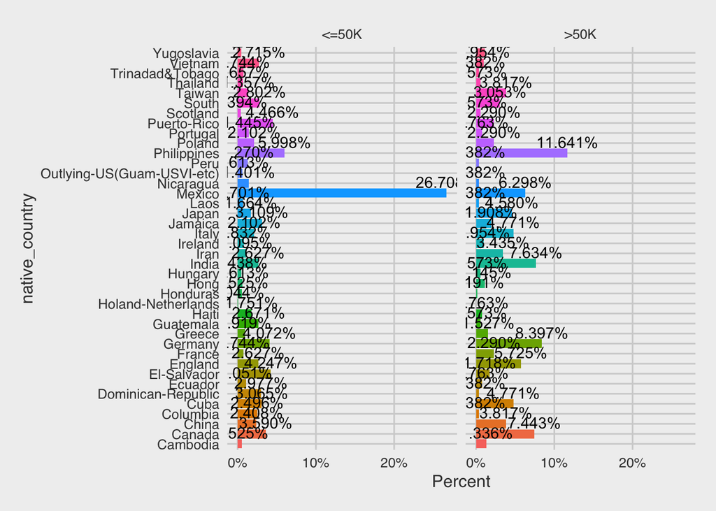

```r
ggplot(filt_cat_vars, aes(x= native_country,  group=income)) +
    geom_bar(aes(y = ..prop.., fill = factor(..x..)), stat="count") +
    geom_text(aes( label = scales::percent(..prop..),
                   y= ..prop.. ), stat= "count", vjust = -.5) +
    labs(y = "Percent", fill="native_country") +
    facet_grid(~income) +
    scale_y_continuous(labels = scales::percent)+coord_flip()+theme(legend.position = "none")
```

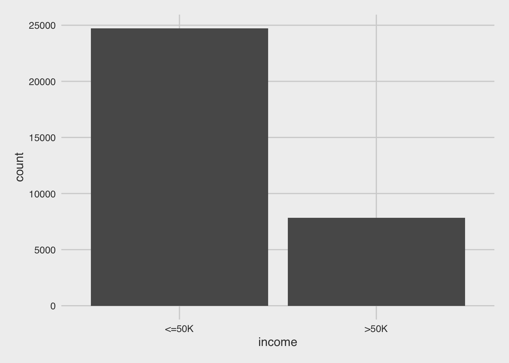

```r
ggplot(cat_vars, aes(x= income)) + geom_bar()
```

```r
#75.919% of observations are <50K
dim(cat_vars[cat_vars$income=='<=50K',])[1]/
  (dim(cat_vars[cat_vars$income=='>50K',])[1]+dim(cat_vars[cat_vars$income=='<=50K',])[1])
```

```
## [1] 0.7591904
```

Looking at Numerical Variables

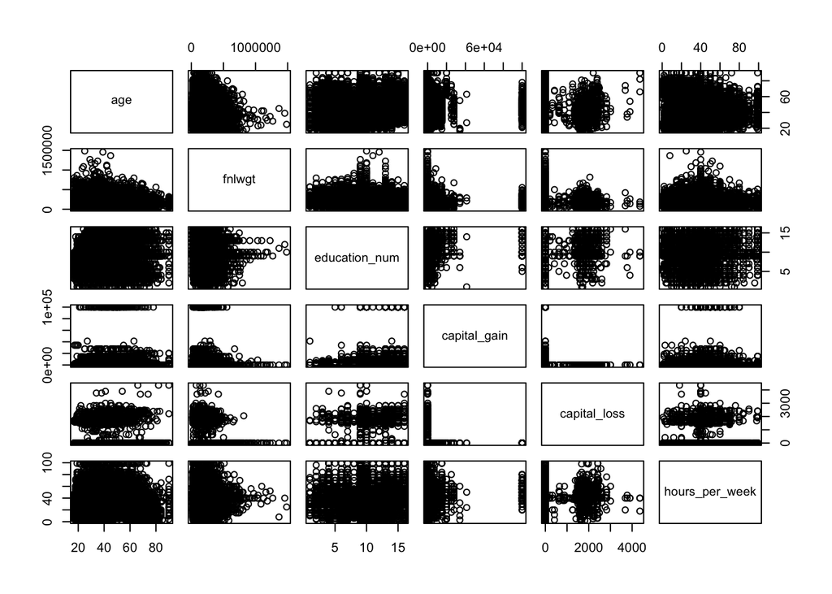

```r
num_vars=adult %>% select_if(is.numeric)
num_vars$income=adult$income
num_vars$income=factor(num_vars$income)
plot(num_vars[,1:6])
```

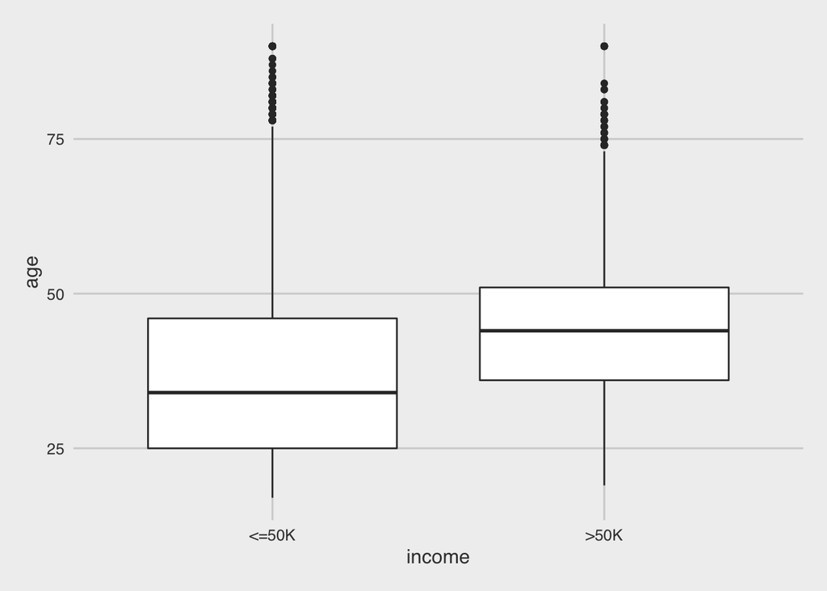

```r
num_vars %>% ggplot(aes(x=income,y=age))+geom_boxplot()
```

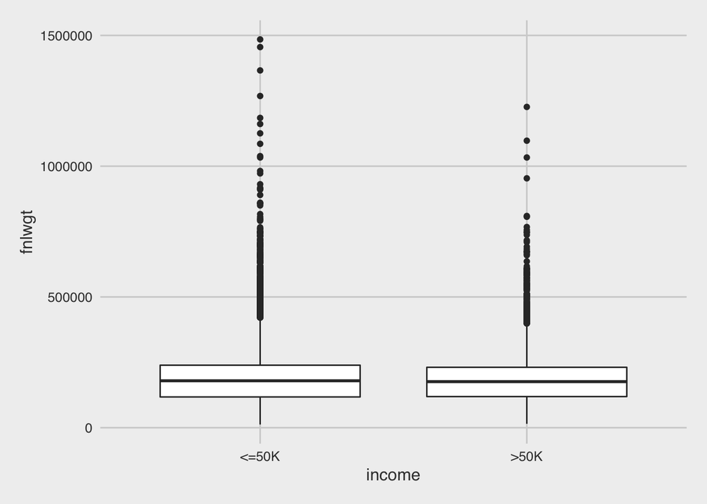

```r
#older people have higher income
num_vars %>% ggplot(aes(x=income,y=fnlwgt))+geom_boxplot()
```

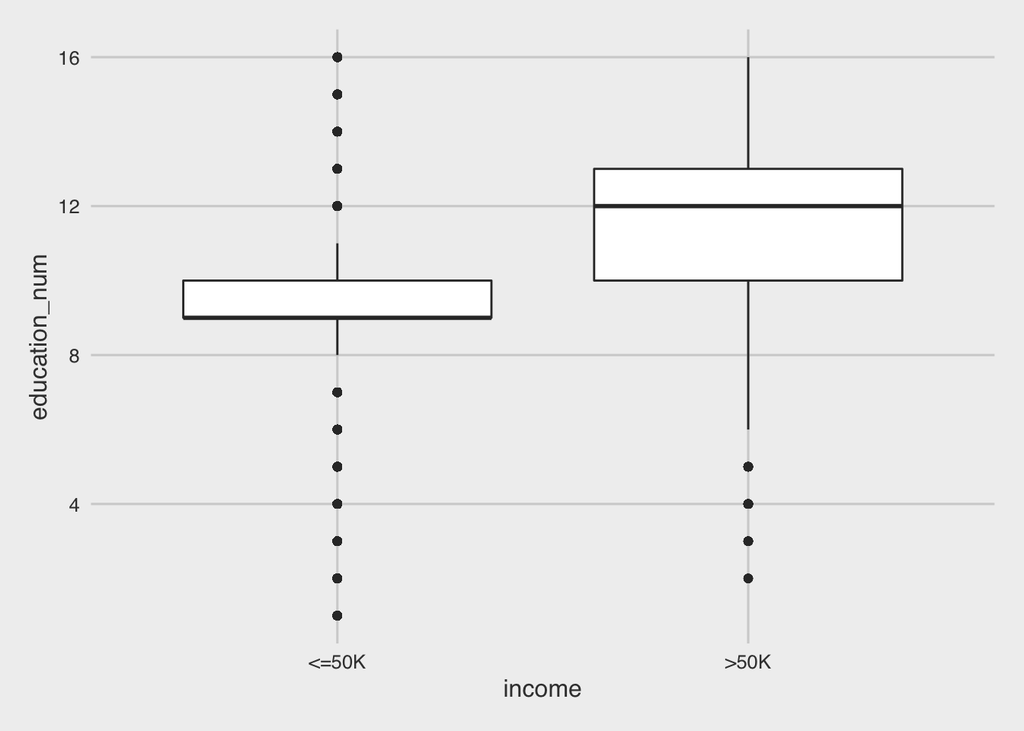

```r
#Education is significantly higher (we should think about if it will cause an issue to include both education variables)
num_vars %>% ggplot(aes(x=income,y=education_num))+geom_boxplot()
```

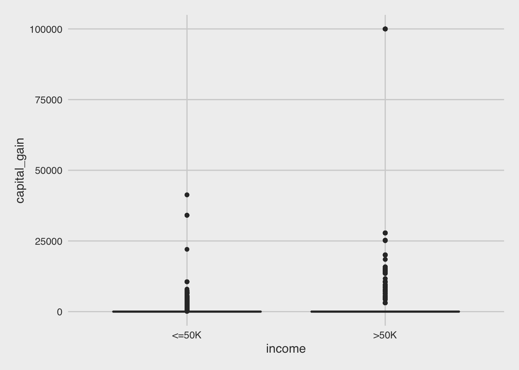

```r
#Investigate probability if gains are more likely for higher income
num_vars %>% ggplot(aes(x=income,y=capital_gain))+geom_boxplot()
```

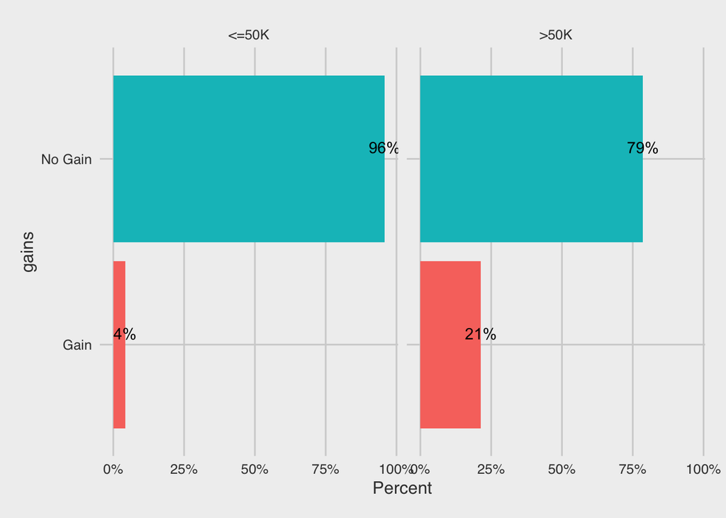

```r
#Testing relation of gains and losses on income
gl_test1=num_vars
gl_test2=num_vars
gl_test1$gains=ifelse(gl_test1$capital_gain>0,'Gain','No Gain')
gl_test2$losses=ifelse(gl_test1$capital_loss>0,'Loss','No Loss')
gl_test1$gains=factor(gl_test1$gains)
gl_test2$losses=factor(gl_test2$losses)

ggplot(gl_test1, aes(x= gains,  group=income)) +
    geom_bar(aes(y = ..prop.., fill = factor(..x..)), stat="count") +
    geom_text(aes( label = scales::percent(..prop..),
                   y= ..prop.. ), stat= "count", vjust = -.5) +
    labs(y = "Percent", fill="gains") +
    facet_grid(~income) +
    scale_y_continuous(labels = scales::percent)+coord_flip()+theme(legend.position = "none")
```

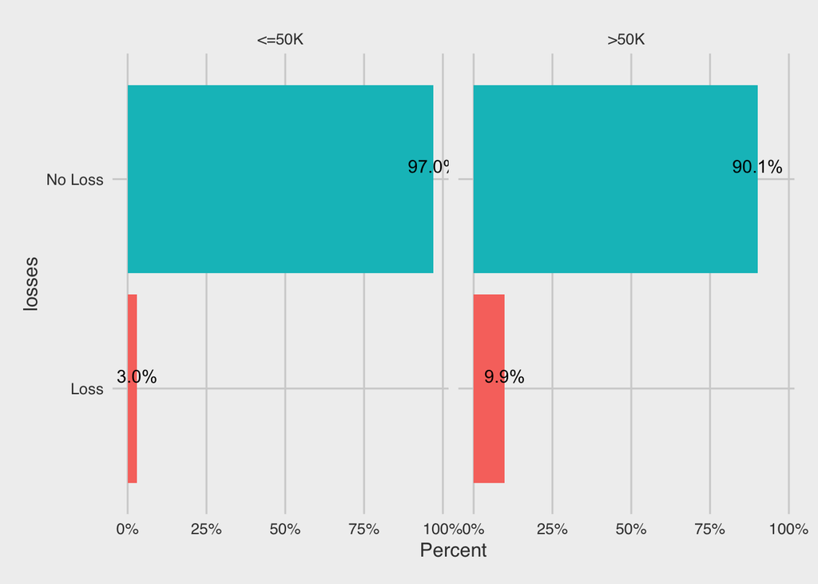

```r
ggplot(gl_test2, aes(x= losses,  group=income)) +
    geom_bar(aes(y = ..prop.., fill = factor(..x..)), stat="count") +
    geom_text(aes( label = scales::percent(..prop..),
                   y= ..prop.. ), stat= "count", vjust = -.5) +
    labs(y = "Percent", fill="gains") +
    facet_grid(~income) +
    scale_y_continuous(labels = scales::percent)+coord_flip()+theme(legend.position = "none")
```

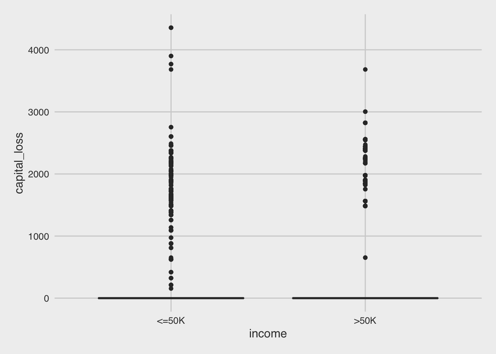

```r
#Investigate probability if losses are more likely for lower income
num_vars %>% ggplot(aes(x=income,y=capital_loss))+geom_boxplot()
```

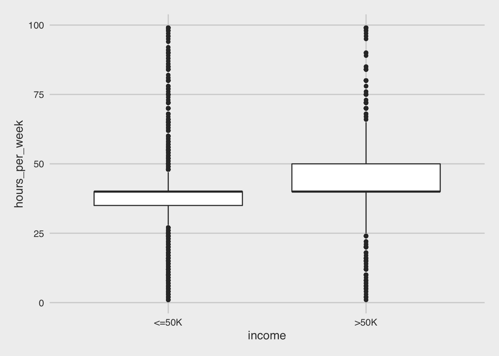

```r
num_vars %>% ggplot(aes(x=income,y=hours_per_week))+geom_boxplot()
```

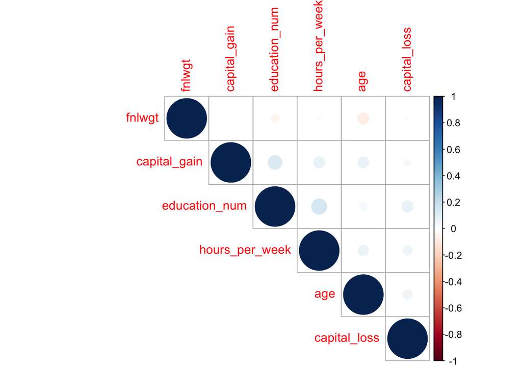

```r
#Generate a correlation and significance table and plot for all vars
res2 <- rcorr(as.matrix(num_vars[,1:6]),type="pearson")
corrplot(res2$r, type="upper", order="hclust",
         p.mat = res2$P, sig.level =  0.1, insig = "blank")
```

```r
#Test variables with Wilcox Test for significance
vars_num=variable.names(num_vars[,-7])
p_matrix= matrix(nrow=length(num_vars)-1, ncol=3)
for (i in 1:length(vars_num)){
a=wilcox.test(num_vars[,(i)]~num_vars$income,alternative="two.sided")
p_matrix[i,1]=vars_num[i]
p_matrix[i,2]=a[[3]]
p_matrix[i,3]=ifelse(a[[3]]<=.05,"keep","remove")
}

p_matrix
```

```
##      [,1]             [,2]                    [,3]
## [1,] "age"            "0"                     "keep"
## [2,] "fnlwgt"         "0.0526819376884781"    "remove"
## [3,] "education_num"  "0"                     "keep"
## [4,] "capital_gain"   "0"                     "keep"
## [5,] "capital_loss"   "7.02129357933078e-143" "keep"
## [6,] "hours_per_week" "0"                     "keep"
```